# Blackwell’s product mix

Isabel de Miguel

17/02/2020

### Predicting product sales and the impact of customers and service reviews

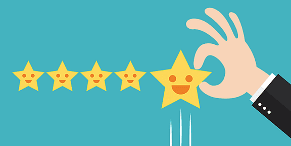

### Background

Blackwell’s sales department is planning to add new products to the company’s product mix, for that reason, they have requested to us to predict potential product sales of these new products, concretely **PC, Laptops, Netbooks and Smartphones** based on the historical sales of existing products.

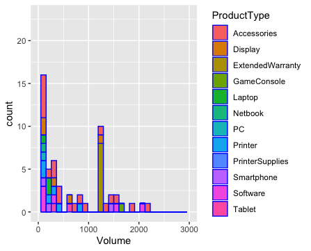

Historical sales of existing product mix

We’ll analyse every attribute given to see which one is relevant for our prediction, in other words, which variable is specially affecting to volume sales, but they has asked to us to pay special attention on **services and customer reviews**.

### Highlights

- We have a small database, with **only 80 rows of sales performance tracking**. It allows us to make predictions with certain precision, but **the small sample doesn’t let to them to be representative to the reality**.
- Concerning the products required for the analysis, we can conclude with the information available that none of the 4 requested products are the ones which more volume sales have, neither the more profitability provide: **Tablet and Game Console are the top 2 in terms of volume and profit**.

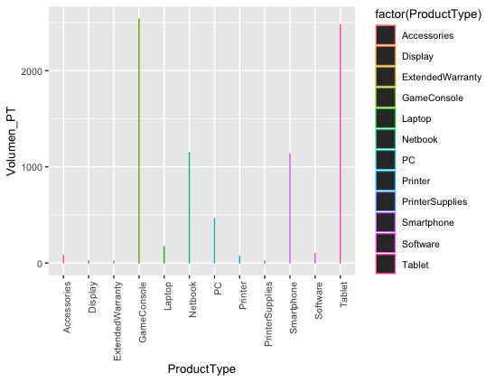

Prediction of Volume by product type

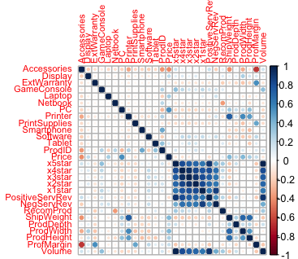

Correlation between variables

### Data and methodology

- Two data sets: **existing products and new products attributes**.
  - Existing products: 80 rows, 18 columns.
  - New products: 25 rows, 18 columns.
- Response variable: **Volume**.
- Regresion problem, worked in R.
- Algorithms: **lm, SVM, KNN, Random Forest** to predict sales of four product types from the new products list.

### Importing and exploring data

On the very first step, after installing libraries we upload both data sets and make an initial exploration just to familiarize ourselves with the data:

```r
# Importing data
existingprod <- read_csv("~/Desktop/Ubiqum/Módulo 2/Task 3/Data/existingproductattributes2017.csv")
newprod <- read_csv("~/Desktop/Ubiqum/Módulo 2/Task 3/Data/newproductattributes2017.csv")

# Data exploration 1
summary(existingprod)
plot(existingprod$Volume)
qqnorm(existingprod$Volume)
boxplot(existingprod$Volume)
```